# Personalised Medicine - EDA with tidy R

# Introduction

This is a comprehensive Exploratory Data Analysis for the [Personalized Medicine: Redefining Cancer Treatment](https://www.kaggle.com/c/msk-redefining-cancer-treatment) challenge. Using *ggplot2* and the *tidyverse* tools to study and visualise the structures in the data.

Challenge to automatically classify genetic mutations that contribute to cancer tumor growth (so-called “drivers”) in the presence of mutations that don’t affect the tumors (“passengers”).

The data comes in 4 different files. Two csv files and two text files:

- *training/test variants:* These are csv catalogues of the gene mutations together with the target value *Class*, which is the (manually) classified assessment of the mutation. The feature variables are *Gene*, the specific gene where the mutation took place, and *Variation*, the nature of the mutation. The test data of course doesn’t have the *Class* values. This is what we have to predict. These two files each are linked through an *ID* variable to another file each, namely:
- *training/test text:* Those contain an extensive description of the evidence that was used (by experts) to manually label the mutation classes.

The text information holds the key to the classification problem and will have to be understood/modelled well to achieve a useful accuracy.

## Load libraries and data files

```r
library('ggplot2') # visualization
library('ggthemes') # visualization
library('scales') # visualization
library('grid') # visualisation
library('gridExtra') # visualisation
library('corrplot') # visualisation
library('ggraph') # visualisation
library('igraph') # visualisation
library('dplyr') # data manipulation
library('readr') # data input
library('tibble') # data wrangling
library('tidyr') # data wrangling
library('stringr') # string manipulation
library('forcats') # factor manipulation
library('tidytext') # text mining
library('SnowballC') # text analysis
library('wordcloud') # test visualisation
```

Reading in the variants data tables:

```r
train <- read.csv('training_variants.csv')
test  <- read.csv('test_variants.csv')
```

Reading in the text files currently takes a bit more effort in R. **The previous read-in method didn’t work properly. Use this one instead:**

```r
train_txt_dump <- tibble(text = read_lines('training_text.txt', skip = 1))
train_txt <- train_txt_dump %>%
  separate(text, into = c("ID", "txt"), sep = "\\|\\|")
train_txt <- train_txt %>%
  mutate(ID = as.integer(ID))
test_txt_dump <- tibble(text = read_lines('test_text.txt', skip = 1))
test_txt <- test_txt_dump %>%
  separate(text, into = c("ID", "txt"), sep = "\\|\\|")
test_txt <- test_txt %>%
  mutate(ID = as.integer(ID))
```

# The variants data tables

We start this EDA with a look at the *variants* data files, which are more easily accessible through common visualisation tools.

## First table overviews of the data:

```r
train <- train %>%
  mutate(Gene = factor(Gene),
         Variation = factor(Variation),
         Class = factor(Class))

test <- test %>%
  mutate(Gene = factor(Gene),
         Variation = factor(Variation))

summary(train, maxsum = 9)
```

```
##        ID            Gene                     Variation    Class
##  Min.   :   0   BRCA1  : 264   Truncating Mutations:  93   1:568
##  1st Qu.: 830   TP53   : 163   Deletion            :  74   2:452
##  Median :1660   EGFR   : 141   Amplification       :  71   3: 89
##  Mean   :1660   PTEN   : 126   Fusions             :  34   4:686
##  3rd Qu.:2490   BRCA2  : 125   Overexpression      :   6   5:242
##  Max.   :3320   KIT    :  99   G12V                :   4   6:275
##                 BRAF   :  93   E17K                :   3   7:953
##                 ALK    :  69   Q61H                :   3   8: 19
##                 (Other):2241   (Other)             :3033   9: 37
```

```r
glimpse(train)
```

```
## Observations: 3,321
## Variables: 4
## $ ID        <int> 0, 1, 2, 3, 4, 5, 6, 7, 8, 9, 10, 11, 12, 13, 14, 15...
## $ Gene      <fct> FAM58A, CBL, CBL, CBL, CBL, CBL, CBL, CBL, CBL, CBL,...
## $ Variation <fct> Truncating Mutations, W802*, Q249E, N454D, L399V, V3...
## $ Class     <fct> 1, 2, 2, 3, 4, 4, 5, 1, 4, 4, 4, 4, 4, 4, 5, 4, 1, 4...
```

```r
nrow(train)
```

```
## [1] 3321
```

```r
nrow(test)
```

```
## [1] 5668
```

```r
sum(is.na(train))
```

```
## [1] 0
```

```r
sum(is.na(test))
```

```
## [1] 0
```

```r
train %>%
  group_by(Gene) %>%
  summarise(ct = n()) %>%
  arrange(desc(ct))
```

```
## # A tibble: 264 x 2
##    Gene      ct
##    <fct>  <int>
##  1 BRCA1    264
##  2 TP53     163
##  3 EGFR     141
##  4 PTEN     126
##  5 BRCA2    125
##  6 KIT       99
##  7 BRAF      93
##  8 ALK       69
##  9 ERBB2     69
## 10 PDGFRA    60
## # ... with 254 more rows
```

```r
test %>%
  group_by(Gene) %>%
  summarise(ct = n()) %>%
  arrange(desc(ct))
```

```
## # A tibble: 1,397 x 2
##    Gene     ct
##    <fct> <int>
##  1 F8      134
##  2 CFTR     57
##  3 F9       54
##  4 G6PD     46
##  5 GBA      39
##  6 AR       38
##  7 PAH      38
##  8 CASR     37
##  9 ARSA     30
## 10 BRCA1    29
## # ... with 1,387 more rows
```

```r
train %>%
  group_by(Variation) %>%
  summarise(ct = n()) %>%
  arrange(desc(ct))
```

```
## # A tibble: 2,996 x 2
##    Variation               ct
##    <fct>                <int>
##  1 Truncating Mutations    93
##  2 Deletion                74
##  3 Amplification           71
##  4 Fusions                 34
##  5 Overexpression           6
##  6 G12V                     4
##  7 E17K                     3
##  8 Q61H                     3
##  9 Q61L                     3
## 10 Q61R                     3
## # ... with 2,986 more rows
```

```r
test %>%
  group_by(Variation) %>%
  summarise(ct = n()) %>%
  arrange(desc(ct))
```

```
## # A tibble: 5,628 x 2
##    Variation               ct
##    <fct>                <int>
##  1 Truncating Mutations    18
##  2 Deletion                14
##  3 Amplification            8
##  4 Fusions                  3
##  5 G44D                     2
##  6 A101V                    1
##  7 A1020P                   1
##  8 A1028V                   1
##  9 A1035V                   1
## 10 A1038V                   1
## # ... with 5,618 more rows
```

We find:

- There are 3321 different *IDs* in the training set containing 264 different *Gene* expressions with 2996 different *Variations*. There are 9 different *Classes* indicated by integer levels.
- The *Gene* and *Variation* features contain character strings of various lengths.
- There is 70% more test data than train data. The data description tells us that “Some of the test data is machine-generated to prevent hand labeling.”, which should explain this otherwise curious imbalance.
- There are no missing values in the variants data.
- The most frequent *Genes* in the train vs test data are complete different. In addition, the test data seems to contain significantly more different *Genes* and fewer high-frequency *Genes* than the train data. To some extent, this might be an effect of the added machine-generate entries in the test data (by adding many different random levels). Thereby, the difference in frequency might mirror the true fraction of effective test data over train data.
- In contrast, the most frequent *Variations* in train vs test are largely identical; although, again, the corresponding frequencies are lower in the test data (by a factor of 5 - 10).

## Individual feature visualisations

This is the frequency distribution of the most frequent *Gene* values:

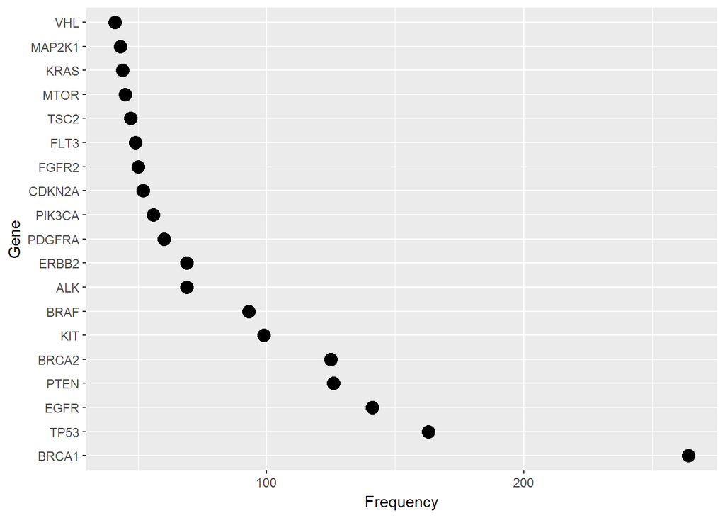

Fig. 1

```r
top_gene <- train %>%
  group_by(Gene) %>%
  summarise(ct = n()) %>%
  filter(ct > 40)

top_gene %>%
  ggplot(aes(reorder(Gene, -ct, FUN = min), ct)) +
  geom_point(size = 4) +
  labs(x = "Gene", y = "Frequency") +
  coord_flip()
```

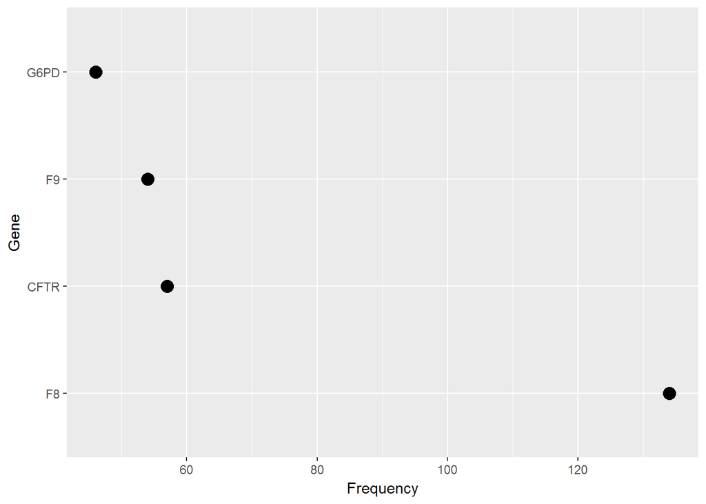

Fig. 2

```r
top_gene_test <- test %>%
  group_by(Gene) %>%
  summarise(ct = n()) %>%
  filter(ct > 40)

top_gene_test %>%
  ggplot(aes(reorder(Gene, -ct, FUN = min), ct)) +
  geom_point(size = 4) +
  labs(x = "Gene", y = "Frequency") +
  coord_flip()
```

We find:

- A relatively small group of *Gene* levels make up a sizeable part of the feature values in both train and test data.
- The test data has fewer high-frequency *Genes*.

These are the most frequent *Variations* in the train (blue) vs test (red) data; confirming what we already saw by comparing the table data:

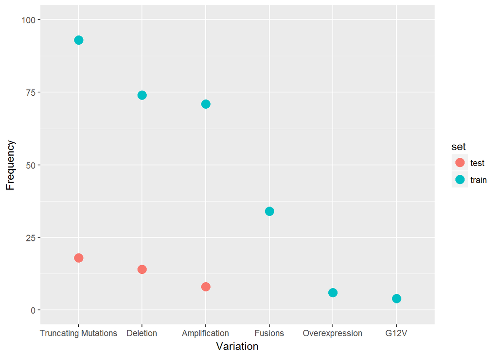

Fig. 3

```r
foo <- train %>% mutate(set = factor("train")) %>% select(-Class, -ID)
bar <- test %>% mutate(set = factor("test")) %>% select(-ID)

foo <- full_join(foo, bar)

foo %>%
  group_by(Variation, set) %>%
  summarise(ct = n()) %>%
  filter(ct > 3) %>%
  ggplot(aes(reorder(Variation, -ct, FUN = median), ct, colour = set)) +
  geom_point(size = 4) +
  coord_cartesian(ylim = c(0, 100)) +
  labs(x = "Variation", y = "Frequency")
```

Here we see how the *Class* target is distributed in the train data:

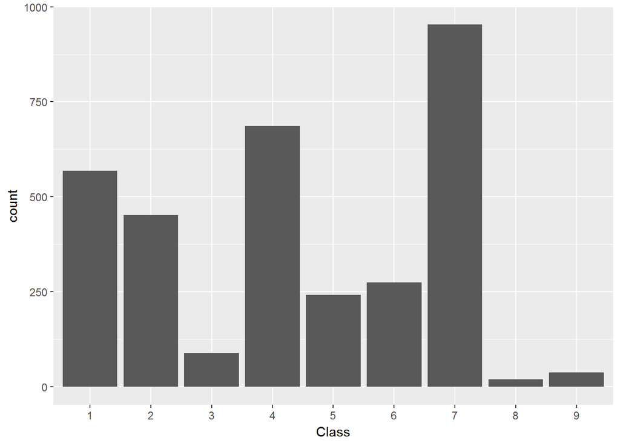

Fig. 4

```r
train %>%
  ggplot(aes(Class)) +
  geom_bar()
```

We find:

- *Class* levels 3, 8, and 9 are notably under-represented
- Levels 5 and 6 are of comparable, medium-low frequency
- Levels 1, 2, and 4 are of comparable, medium-high frequency
- Level 7 is clearly the most frequent one

## Feature interactions

Now we want to examine how the features interact with each other and with the target *Class* variable.

### *Gene* vs *Class*

First, we will look at the frequency distribution of the overall most frequent *Genes* for the different *Classes*. Note the logarithmic frequency scale.

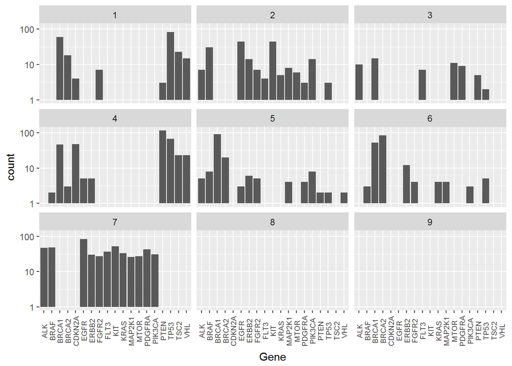

Fig. 5

```r
train %>%
  filter(Gene %in% str_c(top_gene$Gene)) %>%
  ggplot(aes(Gene)) +
  geom_bar() +
  scale_y_log10() +
  theme(axis.text.x  = element_text(angle=90, vjust=0.5, size=7)) +
  facet_wrap(~ Class)
```

We see immediately that there are significant differences:

- Some *Genes*, like “PTEN”, are predominatly present in a single *Class* (here: 4).
- Other *Genes*, like “TP53”, are mainly shared between 2 classes (here: 1 and 4).
- *Classes* 8 and 9 contain none of the most frequent *Genes*.

Here’s what it looks like for the *Classes* sorted by *Genes* (again log counts):

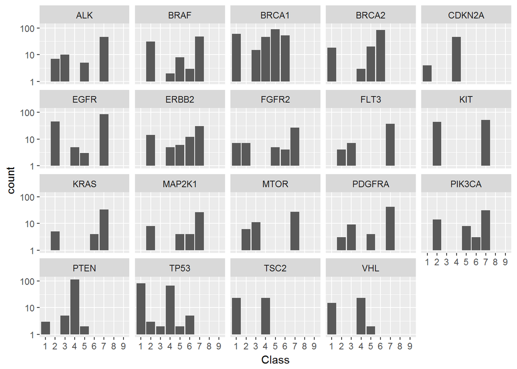

Fig. 6

```r
train %>%
  filter(Gene %in% str_c(top_gene$Gene)) %>%
  ggplot(aes(Class)) +
  geom_bar() +
  scale_y_log10() +
  facet_wrap(~ Gene)
```

This representation underlines our findings about the similar/dominating *Genes* in different *Classes*.

### *Gene* vs *Variation*

Next, we are somewhat repurposing a count plot to visualise how the *Variations* are distributed for the most frequent *Genes*. Since there are so many different variations we drop the y-axis labels and merely illustrate how many *Gene* - *Variation* combinations exist in the data.

First the training data:

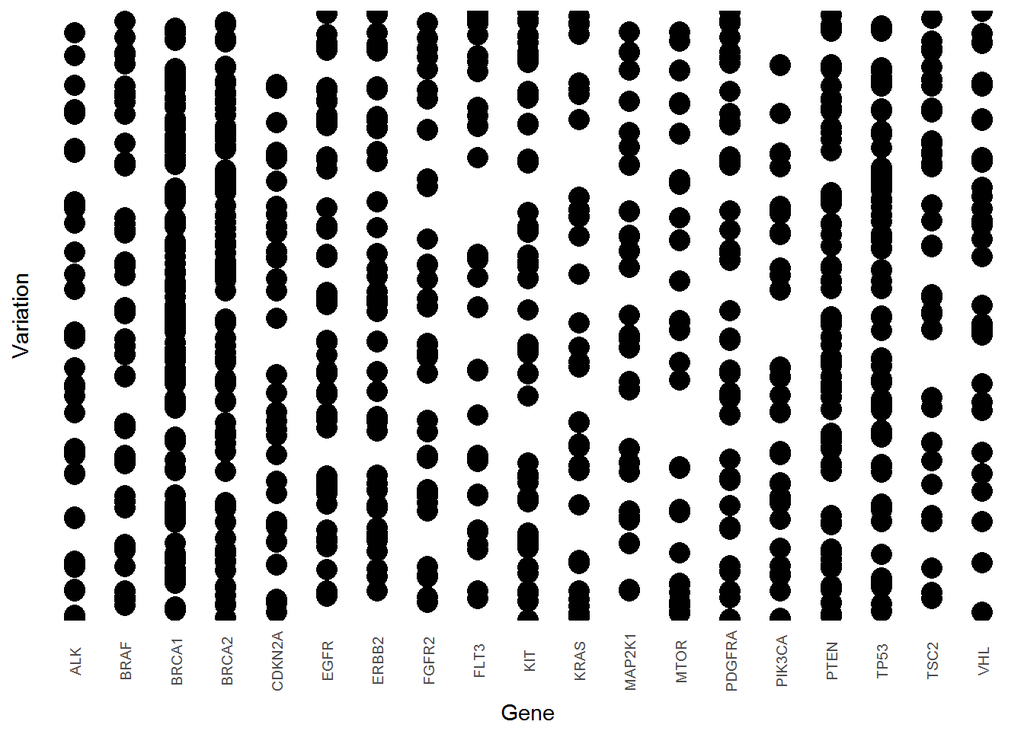

Fig. 7

```r
foo <- train %>%
  filter(Gene %in% str_c(top_gene$Gene)) %>%
  group_by(Gene, Variation) %>%
  summarise(ct = n())

y_labels <- str_sub(foo$Variation, start = 1, end = 5)

foo %>%
  ggplot(aes(reorder(Gene, ct, FUN = median), reorder(Variation, ct, FUN = median))) +
  geom_count() +
  labs(x = "Gene", y = "Variation") +
  theme(axis.text.x  = element_text(angle=90, vjust=0.5, size=7),
        axis.ticks = element_blank(), axis.text.y = element_blank(),
        legend.position = "none")
```

Then the test data:

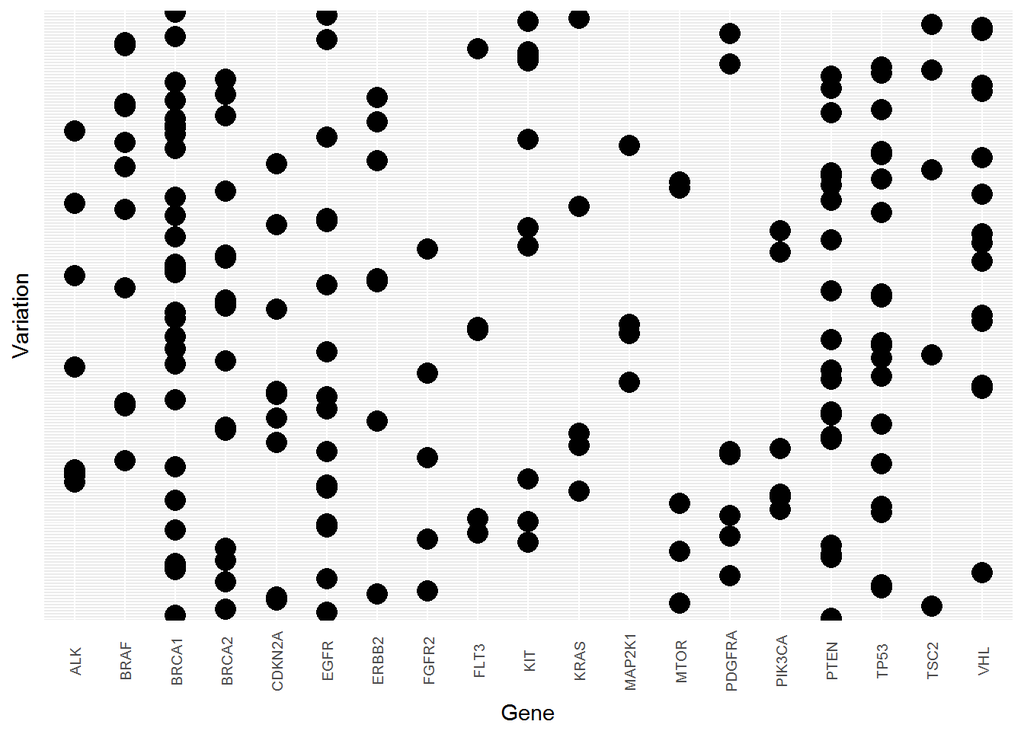

Fig. 8

```r
foo <- test %>%
  filter(Gene %in% str_c(top_gene$Gene)) %>%
  group_by(Gene, Variation) %>%
  summarise(ct = n())

y_labels <- str_sub(foo$Variation, start = 1, end = 5)

foo %>%
  ggplot(aes(reorder(Gene, ct, FUN = median), reorder(Variation, ct, FUN = median))) +
  geom_count() +
  labs(x = "Gene", y = "Variation") +
  theme(axis.text.x  = element_text(angle=90, vjust=0.5, size=7),
        axis.ticks = element_blank(), axis.text.y = element_blank(),
        legend.position = "none")
```

Once more, the two data sets are rather heterogeneous in this view.

# The text files

## Overview

The second kind of data files contain a whole lot of text from what looks like scientific papers or proceedings. Here is the beginning of the first entry:

```r
str_sub(train_txt$txt[1], start = 1, end = 1e3)
```

```
## [1] "Cyclin-dependent kinases (CDKs) regulate a variety of fundamental cellular processes. CDK10 stands out as one of the last orphan CDKs for which no activating cyclin has been identified and no kinase activity revealed. Previous work has shown that CDK10 silencing increases ETS2 (v-ets erythro…
```

Sure enough, we can easily confirm that the first part of the complete entry corresponds to [this paper](https://www.ncbi.nlm.nih.gov/labs/pubmed/24218572-cdk10cyclin-m-is-a-protein-kinase-that-controls-ets2-degradation-and-is-deficient-in-star-syndrome/) and later switches to [this one](https://www.nature.com/ng/journal/v40/n3/pdf/ng.86.pdf?origin=ppub) (and maybe other related ones.) Therefore, this data file appears to be a data dump of the complete publication texts for the papers that the classification was based on (including figure captions, manuscript structure, and sometimes affiliations).

I’m suspecting that a little domain knowledge will go a long way here in determining which keywords are important and which ones aren’t. This will be an interesting excercise to see how clearly information is communicated in scientific publications.

## On data cleaning and preparations

Here I want to collect various text features, artefacts, and global properties that I noticed during this initial exploration. This list will likely expand as the kernel grows.

- **Scientific terminology and stop words:** Most scientific papers have a common style of language that will be reasonably homogeneous throughout the text files. Words like “result” or “discuss” will be frequent without necessarily containing any signal for our prediction goal. Therefore, below I define my own list of additional stop words.
- **Research field related stop words:** My impression is that the list of stop words could be extended by including characteristic terms of the overall research field that are so ubiquitous that their high frequency may mask genuinely interesting terms. Words such as “mutation”, “cancer”, or “tumor” appear to be too general to have much distinguishing power here. The TF-IDF below seems to confirm this. It would be interesting to get some feedback from people with domain knowledge about which other terms could a-priori be removed from the text.
- **Paper notation quirks:** Converting the paper text straight to ascii leads to a number of artefacts. None of those will have a big impact individually, but together they might reduce the accuracy of the analysis:
- Citation numbers (as used e.g. by Nature magazine) are attached to the corresponding word
- Occasionally, there are what seems like webpage navigation commands like “SectionNext” embedden in the text
- Author names and affiliations are occasionally included

## Feature Engineering

### Text length - txt_len

```r
train_txt <- train_txt %>%
  mutate(txt_len = str_length(txt),
         set = "train")

test_txt <- test_txt %>%
  mutate(txt_len = str_length(txt),
         set = "test")

combine_txt <- full_join(train_txt,test_txt)
```

For an early exploration we can look at the distribution of the length of the text features. A priori, I wouldn’t expect the length of a paper to be related to the classification outcome; but maybe some classifications require only a single paper while for others it’s necessary to check multiple ones.

First, here is the overall distribution of the text entry lengths in train vs test:

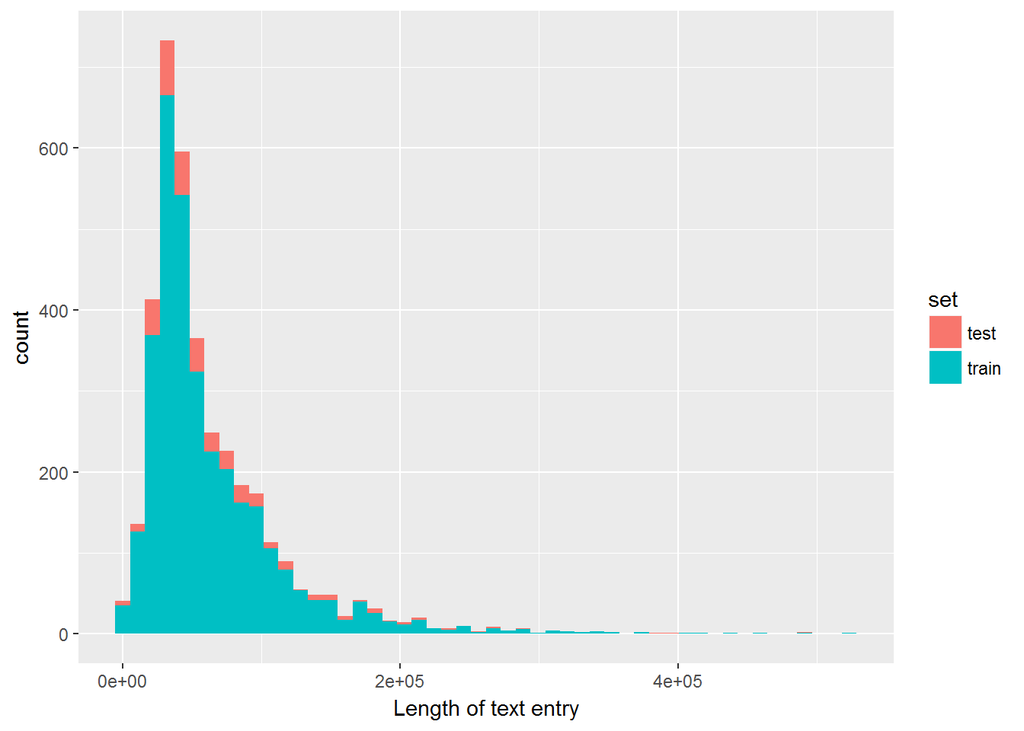

Fig. 9

```r
combine_txt %>%
  ggplot(aes(txt_len, fill = set)) +
#  geom_density(alpha = 0.5, bw = 5e3) +
  geom_histogram(bins = 50) +
  labs(x = "Length of text entry")
```

The difference in distribution shape might again be due to the machine-generated entries that have been added to the test sample.

Now, let’s see whether this distribution changes for the different target *Classes*. First, a facet wrap comparison:

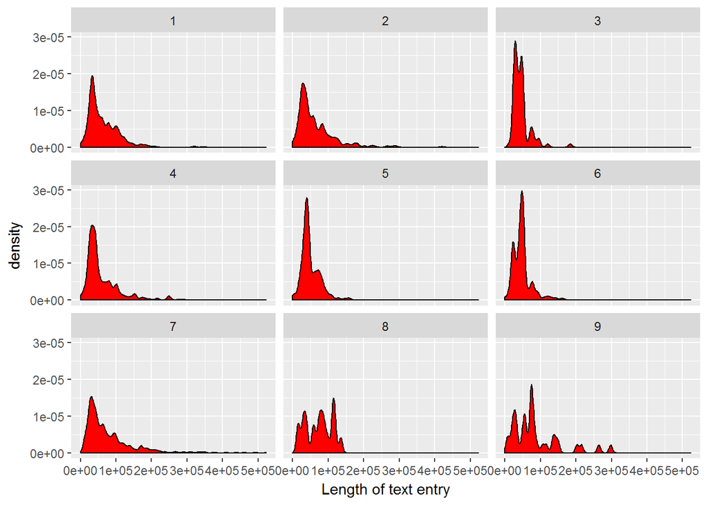

Fig. 10

```r
foo <- train_txt %>%
  select(ID, txt_len)
bar <- train %>%
  select(ID, Class)

full_join(foo, bar, by = "ID") %>%
  ggplot(aes(txt_len)) +
  geom_density(fill = "red", bw = 5e3) +
  labs(x = "Length of text entry") +
  facet_wrap(~ Class)
```

Then an overlay of empirical cumulative density functions:

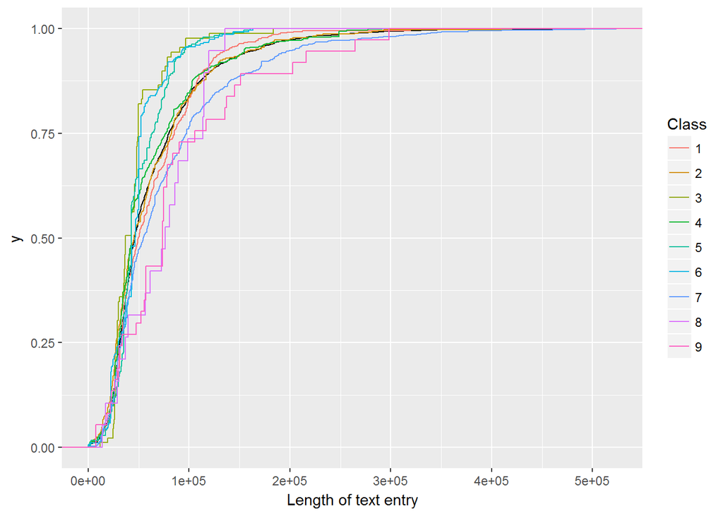

Fig. 11

```r
foo <- train_txt %>%
  select(ID, txt_len)
bar <- train %>%
  select(ID, Class)

full_join(foo, bar, by = "ID") %>%
  ggplot(aes(txt_len)) +
  stat_ecdf(geom = "step") +
  stat_ecdf(aes(txt_len, color = Class), geom = "step") +
  labs(x = "Length of text entry")
```

And the median lengths for each class:

```r
foo <- train_txt %>%
  select(ID, txt_len)
bar <- train %>%
  select(ID, Class)

full_join(foo, bar, by = "ID") %>%
  group_by(Class) %>%
  summarise(l_med = median(txt_len))
```

```
## # A tibble: 9 x 2
##   Class l_med
##   <fct> <dbl>
## 1 1     49582
## 2 2     45434
## 3 3     36901
## 4 4     42790
## 5 5     42863
## 6 6     46289
## 7 7     54675
## 8 8     76146
## 9 9     73433
```

We find:

- There appear to be significant differences in the shape and median of the test length distributions. *Classes* 8 and 9 require on average more text, whereas *Class* 3 has the shortest/fewest papers associated with it.
- For what it’s worth, it is tempting to speculate that the apparent multiple peaks in the text length distributions of the individual *Classes* could correspond to the number of papers that make up the clinical evidence.

### Missing text values

In the discussion it was [pointed out](https://www.kaggle.com/c/msk-redefining-cancer-treatment/discussion/35621) that a few observations have a “null” entry in their *text* features. Using our *txt_len* feature we can confirm this finding and easily show that there are no other *text* values with less than 100 characters (just in case a different Null indicator would have been used):

```r
combine_txt %>%
  filter(txt_len < 100)
```

```
## # A tibble: 6 x 4
##      ID txt     txt_len set
##   <int> <chr>     <int> <chr>
## 1  1109 "null "       5 train
## 2  1277 "null "       5 train
## 3  1407 "null "       5 train
## 4  1639 "null "       5 train
## 5  2755 "null "       5 train
## 6    67 "null "       5 test
```

### Keyword frequency - pedestrian approach

I want to use this competition to learn more about text mining. While I dive deeper into the applications of the various tools and techniques I will document here what I have learnt. If you are a beginner like me, then maybe this approach will be useful for you. If you are an expert then feel free to skip all the entry-level information (and maybe let me know if I get something seriously wrong.)

Before getting started with specialised tools, here is a first approach based on standard string manipulation methods.

An obvious first step in analysing the content of the clinical evidence is to look how often certain keywords are mentioned in the text of the corresponding papers.

We choose the two words “pathogenic” and “benign” that are used in the naming of the 5 categories in [this overview paper](https://www.ncbi.nlm.nih.gov/pmc/articles/PMC4544753/). Here we extract their frequency of occurence per observation:

```r
train_txt <- train_txt %>%
  mutate(f_pathogenic = str_count(txt, "pathogenic"),
         f_benign = str_count(txt, "benign")
         )
```

Those are the frequency distributions of the word “pathogenic” for our 9 classes (note the logarithmic y-axes):

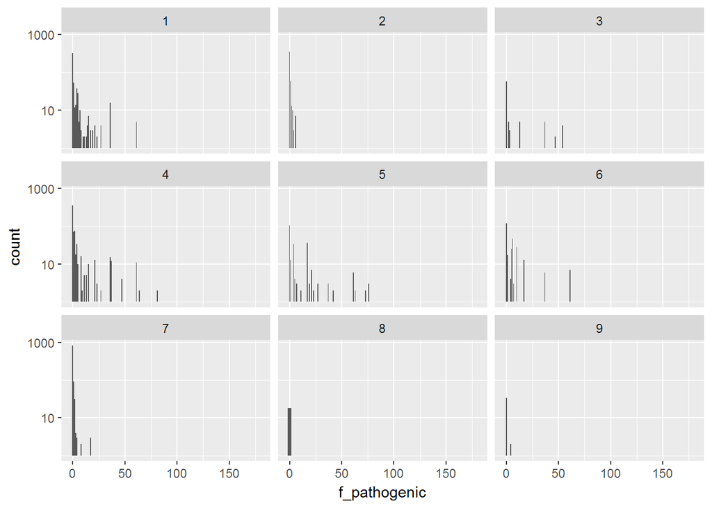

Fig. 12

```r
foo <- train_txt %>%
  select(ID, f_benign, f_pathogenic)
bar <- train %>%
  select(ID, Class)

full_join(foo, bar, by = "ID") %>%
  ggplot(aes(f_pathogenic)) +
  geom_bar() +
  scale_y_log10() +
#  scale_x_log10() +
  facet_wrap(~ Class)
```

And here we plot the ratio of the mean occurence per class of the word “pathogenic” over the mean occurence of the word “benign”:

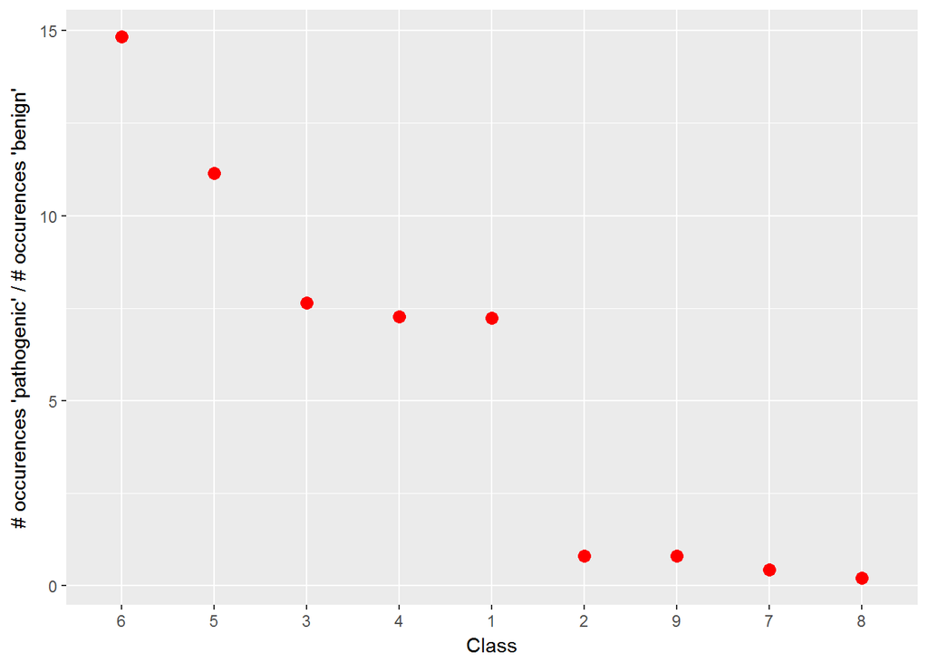

Fig. 13

```r
foo <- train_txt %>%
  select(ID, f_benign, f_pathogenic)
bar <- train %>%
  select(ID, Class)

full_join(foo, bar, by = "ID") %>%
  group_by(Class) %>%
  summarise(mean_benign = mean(f_benign),
            mean_pathogenic = mean(f_pathogenic),
            path_ben = mean(f_pathogenic)/mean(f_benign)) %>%
  ggplot(aes(reorder(Class, -path_ben, FUN = max), path_ben)) +
  geom_point(colour = "red", size = 3) +
  labs(x = "Class", y = "# occurences 'pathogenic' / # occurences 'benign'")
```

We find:

- The facet plot shows that the word “pathogenic” is clearly more frequent in certain *Classes* such as 1, 4, or 5
- The ratio plot confirms this impression and suggests two distinct groups of *Classes*: 2, 7, 8, 9 vs 1, 3, 4. The latter have on average a higher ratio of mentions of “pathogenic” over “benign” than the former. In addition, *Classes* 5 and 6 have an even higher ratio of “pathogenic” over “benign”.

Of course, some of these occurences could have said “not pathogenic” or “not benign”, which is why we will need to dive further into text analysis to tackle this puzzle.

## First steps into text analysis with tidytext

As the authors of the *tidytext* [package](https://cran.r-project.org/web/packages/tidytext/index.html) put it: The tidy text format is being defined as a table with one token per row; with a token being a word or another meaningful unit of text (paraphrased). Through tidy text we can use the powerful tools of the *tidyverse* to process and analyse text files. I will follow [this excellent and free online book](http://tidytextmining.com/).

In order to get our text data in a tidy shape, we use the *unnest_tokens* tool. This also gets rid of punctuation and converts everything to lowercase:

```r
t1 <- train_txt %>% select(ID, txt) %>% unnest_tokens(word, txt)
head(t1)
```

```
## # A tibble: 6 x 2
##      ID word
##   <int> <chr>
## 1     0 cyclin
## 2     0 dependent
## 3     0 kinases
## 4     0 cdks
## 5     0 regulate
## 6     0 a
```

The *tidytext* package contains a dictionary of *stop words*, like “and” or “next”, which we can remove from our tidy text data. In addition, we will define our own selection of stop words based on the typical structuring language of scientific papers. We also remove tokens that are only numbers or symbols.

```r
data("stop_words")
my_stopwords <- data_frame(word = c(as.character(1:100),
                                    "fig", "figure", "et", "al", "table",
                                    "data", "analysis", "analyze", "study",
                                    "method", "result", "conclusion", "author",
                                    "find", "found", "show", "perform",
                                    "demonstrate", "evaluate", "discuss"))
t1 <- t1 %>%
  anti_join(stop_words, by = "word") %>%
  anti_join(my_stopwords, by = "word") %>%
  filter(str_detect(word, "[a-z]"))
```

For a first overview, we have a look at the overall most popular words and their frequencies. This is our first serious application of tidyverse and ggplot2 tools to text data:

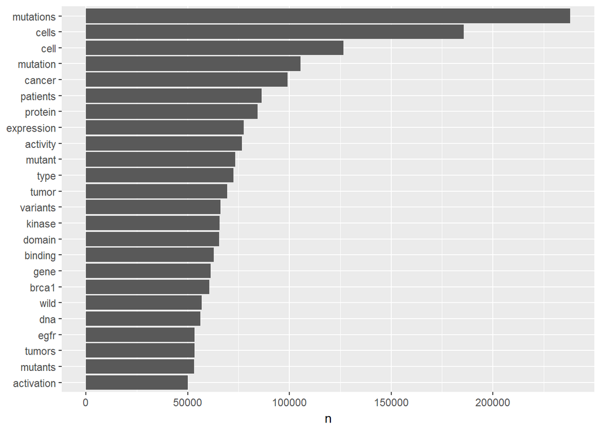

Fig. 14

```r
t1 %>%
  count(word) %>%
  filter(n > 5e4) %>%
  mutate(word = reorder(word, n)) %>%
  ggplot(aes(word, n)) +
  geom_col() +
  xlab(NULL) +
  coord_flip()
```

By and large, those are words that we would expect to find in a publication on cancer research and genetics. You will notice that for instance the top 4 words are essentially 2 variants of two basic words each. For our purposes these word variants are likely to obfuscate the signal we are interested in. We can reduce them to their basic meaning, their *word stem*, using a stemming tool.

As far as I can see, tidytext has currently no native stemming function. Therefore, we will use the “SnowballC” package and its “wordStem” tool:

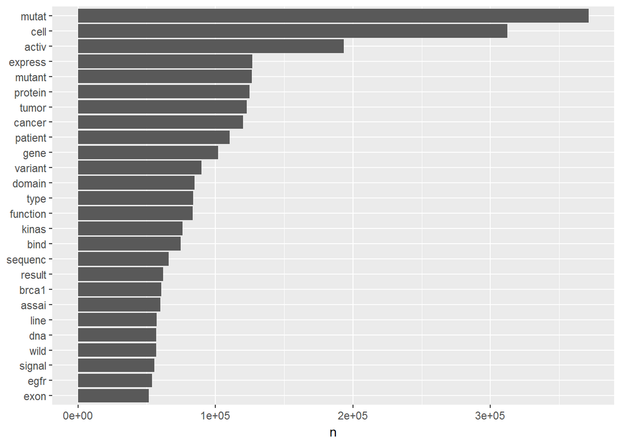

Fig. 15

```r
t1 <- t1 %>%
  mutate(word = wordStem(word))

t1 %>%
  count(word) %>%
  filter(n > 5e4) %>%
  mutate(word = reorder(word, n)) %>%
  ggplot(aes(word, n)) +
  geom_col() +
  xlab(NULL) +
  coord_flip()
```

The result shows us the fundamental words that are most frequent in our overall text data. Another way of visualising these frequencies is through a *wordcloud*. Personally, I suspect that wordclouds might be the text equivalent of pie charts. But it’s useful to know how to incorporate them into tidy text analysis:

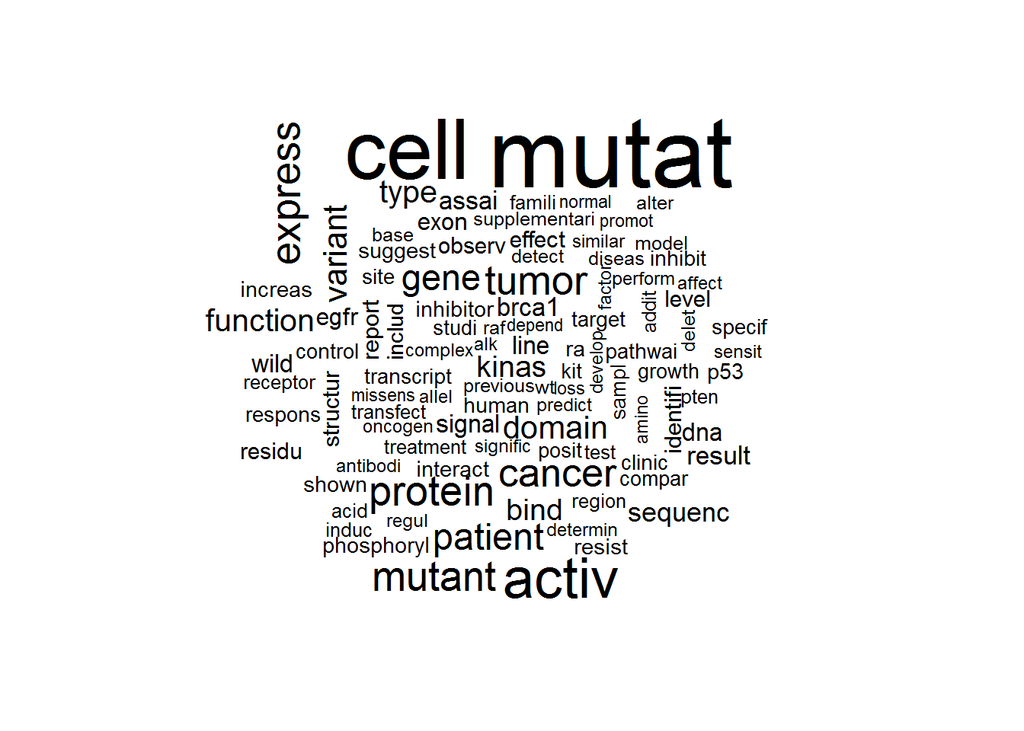

Fig. 16

```r
t1 %>%
  count(word) %>%
  with(wordcloud(word, n, max.words = 100))
```

## Class-dependent word frequencies

In order to use these word frequencies for prediction we first need to determine them for the individual *Classes* separately. Below, we join our “text” data with the *Class* information in the “variants” data set. Afterwards, we determine the relative frequency by *Class* of each word.

```r
foo <- train %>%
  select(ID, Class)

t1_class <- full_join(t1, foo, by = "ID")

frequency <-t1_class %>%
  count(Class, word) %>%
  filter(n > 5e2) %>%
  group_by(Class) %>%
  mutate(freq = n / sum(n)) %>%
  select(-n) %>%
  spread(Class, freq) %>%
  gather(Class, freq, `1`:`2`)
```

Then, for a visual overview, we plot the frequency of the words in *Class* 7 against the other two *Classes* (note the logarithmic axes):

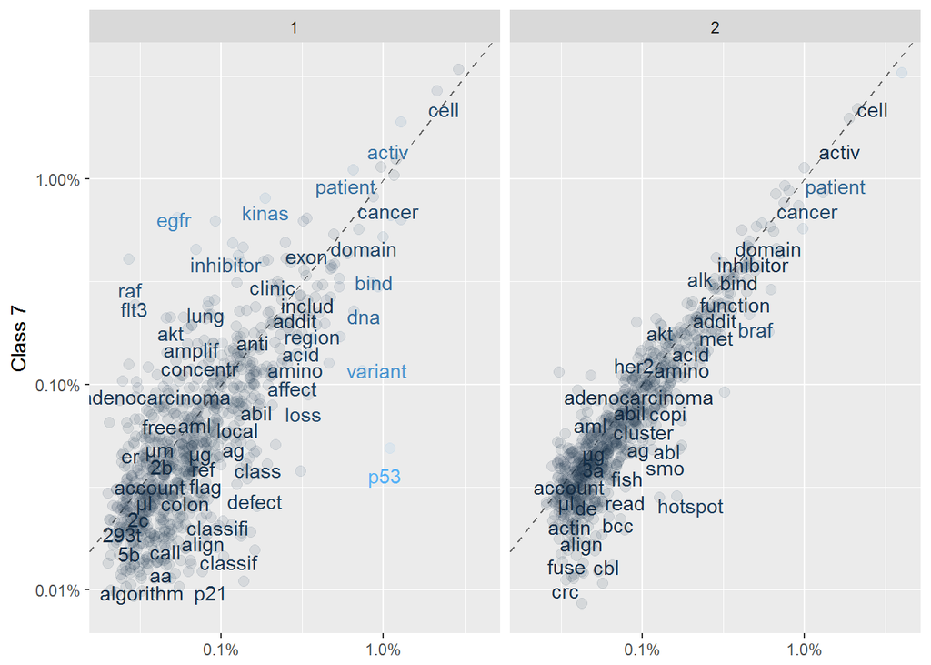

Fig. 17

```r
ggplot(frequency, aes(x = freq, y = `7`, color = abs(`7` - freq))) +
  geom_abline(color = "gray40", lty = 2) +
  geom_jitter(alpha = 0.1, size = 2.5, width = 0.1, height = 0.1) +
  geom_text(aes(label = word), check_overlap = TRUE, vjust = 1.5) +
  scale_x_log10(labels = percent_format()) +
  scale_y_log10(labels = percent_format()) +
  #scale_color_gradient(limits = c(0, 0.001), low = "darkslategray4", high = "gray95") +
  facet_wrap(~Class, ncol = 2) +
  theme(legend.position="none") +
  labs(y = "Class 7", x = NULL)
```

In these plots, words that are close to the dashed line (of equal frequency) have similar frequencies in the corresponding *Classes*. Words that are further along a particular *Class* axis (such as “inhibitor” for *Class* 7 vs 1) are more frequent in that *Class*. The blue-gray scale indicates how different the *Class* 7 frequency is from the overall frequency (with higher relative frequencies being lighter). The (slightly jittered) points in the background represent the complete set of (high-frequency) words, whereas the displayed words have been chosen to avoid overlap.

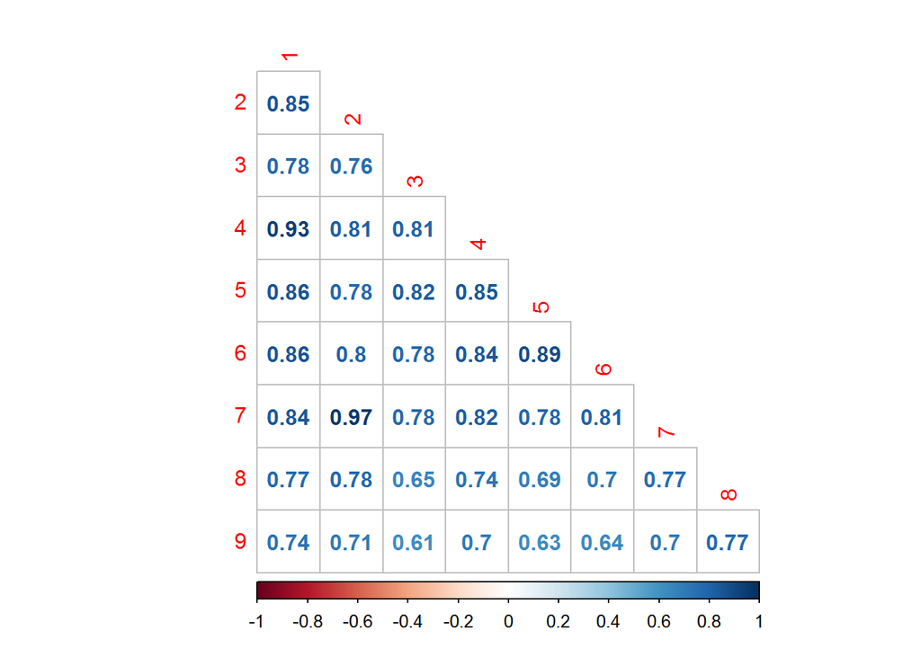

Fig. 18

```r
frequency <-t1_class %>%
  count(Class, word) %>%
  #filter(n > 1e3) %>%
  group_by(Class) %>%
  mutate(freq = n / sum(n)) %>%
  select(-n) %>%
  spread(Class, freq)

frequency %>%
  select(-word) %>%
  cor(use="complete.obs", method="spearman") %>%
  corrplot(type="lower", method="number", diag=FALSE)
```

We find:

- *Classes* 2 and 7 are in fact the most similar ones here, followed by 1 and 4 (correlation coefficients above 0.9)
- Overall, the most different *Class* appears to be number 9, in particular compared to classes 3 and 5 (which are not overwhelming similar to each other). Let’s see what word frequency spread looks like for those combinations:

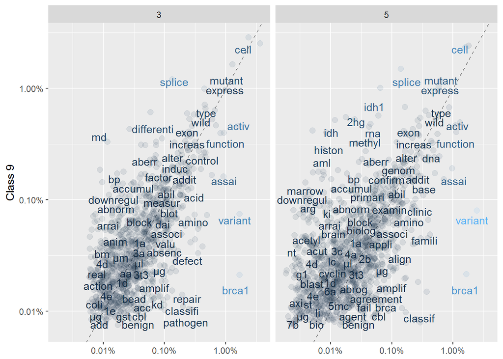

Fig. 19

```r
foo <- train %>%
  select(ID, Class)

t1_class <- full_join(t1, foo, by = "ID")

frequency <-t1_class %>%
  count(Class, word) %>%
  filter(n > 2e1) %>%
  group_by(Class) %>%
  mutate(freq = n / sum(n)) %>%
  select(-n) %>%
  spread(Class, freq) %>%
  gather(Class, freq, `3`,`5`)

ggplot(frequency, aes(x = freq, y = `9`, color = abs(`9` - freq))) +
  geom_abline(color = "gray40", lty = 2) +
  geom_jitter(alpha = 0.1, size = 2.5, width = 0.1, height = 0.1) +
  geom_text(aes(label = word), check_overlap = TRUE, vjust = 1.5) +
  scale_x_log10(labels = percent_format()) +
  scale_y_log10(labels = percent_format()) +
  #scale_color_gradient(limits = c(0, 0.001), low = "darkslategray4", high = "gray95") +
  facet_wrap(~Class, ncol = 2) +
  theme(legend.position="none") +
  labs(y = "Class 9", x = NULL)
```

We find:

- There is significantly more of a scatter than in the previous set of plots; especially for *Class* 5 vs 9.
- Interestingly, both “benign” and “pathogen” are more frequent in *Class* 3 vs 9.

## TF-IDF analysis - basics and application

As the competition progresses you will probably see this combination of acronyms more and more often in kernels and discussion. And as a beginner like me, you might not know right away what it means. Let’s start with the basics:

- TF stands for *term frequency*; essentially how often a word appears in the text. This is what we measured above. A list of stop-words can be used to filter out frequent words that likely have no impact on the question we want to answer (e.g. “and” or “the”). However, using stop words might not always be an elegant approach. IDF to the rescue.
- IDF means *inverse document frequency*. Here, we give more emphasis to words that are rare within a collection of documents (which in our case means the entire text data.)
- Both measures can be combined into *TF-IDF*, a heuristic index telling us how frequent a word is in a certain context (here: a certain *Class*) within the context of a larger document (here: all *Classes*). You can understand it as a normalisation of the relativ text frequency by the overall document frequency. This will lead to words standing out that are characteristic for a specific *Class*, which is pretty much what we want to achieve in order to train a model.

Tidytext has the function *bind_tf_idf* to extract these metrics from a tidy data set that contains words and their counts per *Class*:

```r
frequency <-t1_class %>%
  count(Class, word)

tf_idf <- frequency %>%
  bind_tf_idf(word, Class, n)
```

Let’s visualise the most characteristic words and their *Class*:

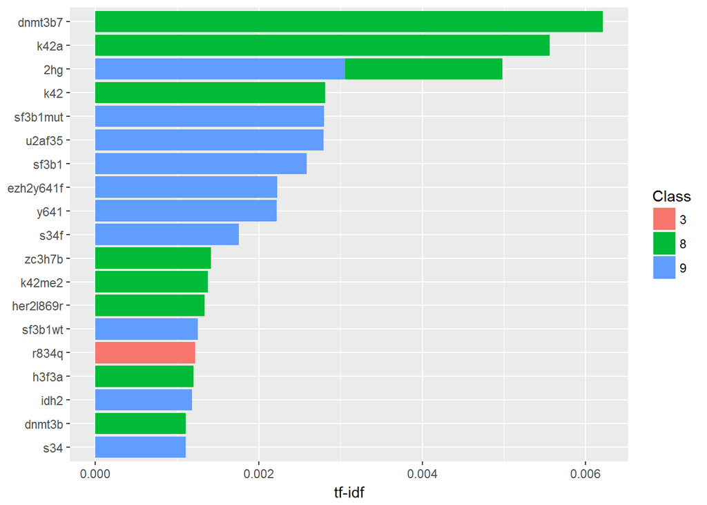

```r
tf_idf %>%
  arrange(desc(tf_idf)) %>%
  mutate(word = factor(word, levels = rev(unique(word)))) %>%
  top_n(20, tf_idf) %>%
  ggplot(aes(word, tf_idf, fill = Class)) +
  geom_col() +
  labs(x = NULL, y = "tf-idf") +
  coord_flip()
```

Well, that looks sufficiently technical I suppose. A quick google search reveals that “dnmt3b7” is in fact an “aberrant splice form of a DNA methyltransferase, DNMT3B7, expressed in virtually all cancer cell lines but at very low levels in normal cells.” ([citation](http://journals.plos.org/plosone/article?id=10.1371/journal.pone.0117310)). Here it seems to be associated to *Class 8*.

Let’s have an overview of the most characteristic terms in each individual *Class*:

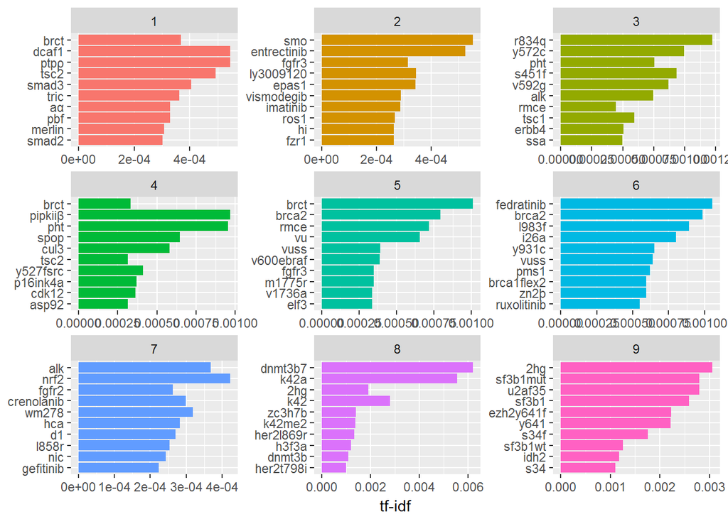

Fig. 20

```r
tf_idf %>%
  arrange(desc(tf_idf)) %>%
  mutate(word = factor(word, levels = rev(unique(word)))) %>%
  group_by(Class) %>%
  top_n(10, tf_idf) %>%
  ungroup() %>%
  ggplot(aes(word, tf_idf, fill = Class)) +
  geom_col() +
  labs(x = NULL, y = "tf-idf") +
  theme(legend.position = "none") +
  facet_wrap(~ Class, ncol = 3, scales = "free") +
  coord_flip()
```

Again, very technical terms here. We notice, though, that some of them (like “brct”) occur in more than one class but still have a high tf-idf.

Thus, this an overview of the different parts of the cancer treatment data which had informtation on genetic mutations that contribute to cancer tumor growth.